# Proj1_kl2739

```r
used <- c("tm", "SnowballC", "RColorBrewer", "ggplot2", "wordcloud", "biclust",
          "cluster", "igraph", "fpc", "dplyr", "plyr", "tidytext", "stringr",
          "rvest", "tibble", "qdap", "sentimentr", "gplots",
                 "syuzhet", "factoextra",
                "beeswarm", "scales",
                "RANN", "topicmodels", "rsconnect" , "xlsx")
# check packages that need to be installed.
needed=setdiff(used, intersect(installed.packages()[,1], used))
# install additional packages
if(length(needed)>0){
  install.packages(needed, dependencies = TRUE,
                   repos='http://cran.us.r-project.org')
}
library(tm)
library(tidytext)
library(dplyr)
library(wordcloud)
library(RColorBrewer)
library(SnowballC)
library(plyr)
library(stringr)
library(rvest)
library(tibble)
library(qdap)
library(sentimentr)
library(gplots)
library(syuzhet)
library(factoextra)
library(beeswarm)
library(scales)
library(RANN)
library(topicmodels)
library(rsconnect)
library(xlsx)
source("../lib/Functions.R")
```

This notebook was prepared with the following environmental settings.

```r
print(R.version)
```

```
               _
platform       x86_64-apple-darwin13.4.0
arch           x86_64
os             darwin13.4.0
system         x86_64, darwin13.4.0
status         Patched
major          3
minor          3.2
year           2017
month          01
day            26
svn rev        72035
language       R
version.string R version 3.3.2 Patched (2017-01-26 r72035)
nickname       Sincere Pumpkin Patch
```

```r
#Read in the speeches
folder.path="../data/InauguralSpeeches/"
speeches=list.files(path = folder.path, pattern = "*.txt")
prex.out=substr(speeches, 6, nchar(speeches)-4)
ff.all<-Corpus(DirSource(folder.path))
#Reading in InaugurationDates.txt
dates <- read.delim("InaugurationDates.txt")
#dates
```

# Step 2 - Text processing, pre-processing stage

For the speeches, we remove extra white space, convert all letters to the lower case, remove [stop words](https://github.com/arc12/Text-Mining-Weak-Signals/wiki/Standard-set-of-english-stopwords), removed empty words due to formatting errors, and remove punctuation. Then we compute the [Document-Term Matrix (DTM)](https://en.wikipedia.org/wiki/Document-term_matrix).

```r
#preprocessing data
ff.all<-tm_map(ff.all, stripWhitespace)
ff.all<-tm_map(ff.all, content_transformer(tolower))
ff.all<-tm_map(ff.all, removeWords, stopwords("english"))
ff.all<-tm_map(ff.all, removeWords, character(0))
ff.all<-tm_map(ff.all, removePunctuation)
#stage the data; create a document term matrix (what we will use from this point on)
#Term-Document Matrix is transpose of Document-Term Matrix
tdm.all<-TermDocumentMatrix(ff.all)
tdm.tidy=tidy(tdm.all)
tdm.overall=ddply(tdm.tidy,.(term),summarise,total_count=sum(count))
```

# Step 3 - Inspect an overall wordcloud

```r
wordcloud(tdm.overall$term, tdm.overall$total_count,
          scale=c(5,0.5),
          max.words=100,
          min.freq=1,
          random.order=FALSE,
          rot.per=0.3,
          use.r.layout=T,
          random.color=FALSE,
          colors=brewer.pal(9,"Blues"))
```

[output not shown]

# Step 4 - compute TF-IDF weighted document-term matrices for individual speeches.

As we would like to identify interesting words for each inaugural speech, we use [TF-IDF](https://en.wikipedia.org/wiki/Tf%E2%80%93idf) to weigh each term within each speech. It highlights terms that are more specific for a particular speech.

```r
dtm <- DocumentTermMatrix(ff.all,
                          control = list(weighting = function(x)
                                             weightTfIdf(x,
                                                         normalize =FALSE),
                                         stopwords = TRUE))
ff.dtm=tidy(dtm)
```

# Step 5- Interactive visualize important words in individual speeches

```r
library(shiny)
library(rsconnect)

shinyApp(
    ui = fluidPage(
      fluidRow(style = "padding-bottom: 20px;",
        column(4, selectInput('speech1', 'Speech 1',
                              speeches,
                              selected=speeches[5])),
        column(4, selectInput('speech2', 'Speech 2', speeches,
                              selected=speeches[9])),
        column(4, sliderInput('nwords', 'Number of words', 3,
                               min = 20, max = 200, value=100, step = 20))
      ),
      fluidRow(
        plotOutput('wordclouds', height = "400px")
      )
    ),

    server = function(input, output, session) {

      # Combine the selected variables into a new data frame
      selectedData <- reactive({
        list(dtm.term1=ff.dtm$term[ff.dtm$document==as.character(input$speech1)],
             dtm.count1=ff.dtm$count[ff.dtm$document==as.character(input$speech1)],
             dtm.term2=ff.dtm$term[ff.dtm$document==as.character(input$speech2)],
             dtm.count2=ff.dtm$count[ff.dtm$document==as.character(input$speech2)])
      })

      output$wordclouds <- renderPlot(height = 400, {
        par(mfrow=c(1,2), mar = c(0, 0, 3, 0))
        wordcloud(selectedData()$dtm.term1,
                  selectedData()$dtm.count1,
              scale=c(4,0.5),
              max.words=input$nwords,
              min.freq=1,
              random.order=FALSE,
              rot.per=0,
              use.r.layout=FALSE,
              random.color=FALSE,
              colors=brewer.pal(10,"Blues"),
            main=input$speech1)
        wordcloud(selectedData()$dtm.term2,
                  selectedData()$dtm.count2,
              scale=c(4,0.5),
              max.words=input$nwords,
              min.freq=1,
              random.order=FALSE,
              rot.per=0,
              use.r.layout=FALSE,
              random.color=FALSE,
              colors=brewer.pal(10,"Blues"),
            main=input$speech2)
      })
    },

    options = list(height = 600)
)
```

```r
freq<-rowSums(as.matrix(tdm.all))
head(sort(freq,decreasing=T),20)
```

```
      will     people government        can       upon       must      great
       912        567        562        469        371        365        339
    states        may      shall      world    country      every     nation
       338        335        310        306        304        299        291
     peace        new        one      power        now     public
       249        247        245        236        226        225
```

```r
findFreqTerms(tdm.all,lowfreq = 125)
```

```
 [1] "america"      "american"     "can"          "citizens"     "congress"
 [6] "constitution" "country"      "every"        "free"         "freedom"
[11] "good"         "government"   "great"        "justice"      "law"
[16] "laws"         "let"          "life"         "made"         "make"
[21] "may"          "men"          "must"         "nation"       "national"
[26] "nations"      "never"        "new"          "now"          "one"
[31] "peace"        "people"       "power"        "public"       "rights"
[36] "shall"        "spirit"       "states"       "time"         "union"
[41] "united"       "upon"         "war"          "well"         "will"
[46] "without"      "world"        "years"
```

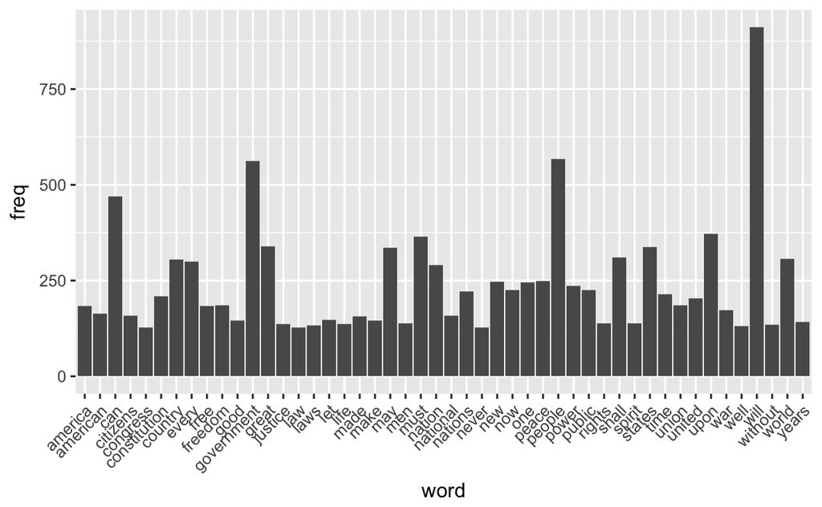

```r
#plot word frequencies
library(ggplot2)
wf <- data.frame(word=names(freq),freq=freq)
p <- ggplot(subset(wf,freq>125), aes(word,freq))
p <- p+ geom_bar(stat="identity")
p <- p+ theme(axis.text.x=element_text(angle=45,hjust=1))
p
```

# Subsetting the Data:

```r
#Select a class of equivalent terms; in this case, we look at "women"
term.vector <- c("women", "woman", "girls", "girl")
#Subset our dataset to include only speeches in which any of the words in term.vector appear
tdm.tidy.women <- get.tdm.tidy.term(tdm.tidy,term.vector)
#Since each word in term.vector is considered equivalent, we use split/apply/combine method to summarize the number of times "women" and its equivalents are mentioned in each speech
(instances.women <- get.instances(tdm.tidy.women))
```

|  | document | total_count |
| --- | --- | --- |
| 1 | inaugBarackObama-1.txt | 5 |
| 8 | inaugGeorgeBush-1.txt | 4 |
| 16 | inaugWoodrowWilson-1.txt | 4 |
| 2 | inaugBarackObama-2.txt | 3 |
| 5 | inaugFranklinDRoosevelt-2.txt | 3 |
| 9 | inaugGeorgeWBush-2.txt | 3 |
| 10 | inaugHerbertHoover-1.txt | 3 |
| 4 | inaugDonaldJTrump-1.txt | 2 |
| 11 | inaugRonaldReagan-1.txt | 2 |
| 12 | inaugRonaldReagan-2.txt | 2 |

[output cut: 6 more lines]

```r
#Use get.speeches(tdm.tidy.term)
speeches.women <- get.speeches(tdm.tidy.women)
#Use get.ff.term(folder.path,speeches.term)
ff.women <- get.ff.term(folder.path,speeches.women)
#Use assoc.words(folder.path,speeches.term,x) , which calls on
  #association(my.corpus,term.vector,x)
(assoc.women <- assoc.words(folder.path,speeches.women,x=10))
```

```
$`inaugBarackObama-1.txt`
  [1] "riches"      "fame"        "rather"      "risktakers"  "doers"
  [6] "makers"      "things"      "celebrated"  "often"       "men"
 [11] "women"       "obscure"     "labor"       "carried"     "us"
 [16] "long"        "rugged"      "path"        "toward"      "prosperity"
 [21] "freedom"     "died"        "places"      "like"        "concord"
 [26] "gettysburg"  "normandy"    "khe"         "sanh"        "time"
 [31] "men"         "women"       "struggled"   "sacrificed"  "worked"
 [36] "til"         "hands"       "raw"         "might"       "live"
 [41] "better"      "life"        "big"         "plans"       "memories"
 [46] "short"       "forgotten"   "country"     "already"     "done"
 [51] "free"        "men"         "women"       "can"         "achieve"
 [56] "imagination" "joined"      "common"      "purpose"     "necessity"
 [61] "courage"     "cynics"      "fail"        "small"       "village"
 [66] "father"      "born"        "know"        "america"     "friend"
```

[output cut: 209 more lines]

```r
#only look at the speeches that mention "women" (and the like)
#should be 16 speeches in the new corpus
#speeches.women <- unique(tdm.tidy.women$document)
#pattern <- paste(speeches.women,collapse ="|")
#ff.women <- Corpus(DirSource(folder.path,pattern=pattern))
#association <- function(my.corpus){
  #preprocessing data
  #my.corpus<-tm_map(my.corpus, stripWhitespace)
  #my.corpus<-tm_map(my.corpus, content_transformer(tolower))
  #my.corpus<-tm_map(my.corpus, removeWords, stopwords("english"))
  #my.corpus<-tm_map(my.corpus, removeWords, character(0))
  #my.corpus<-tm_map(my.corpus, removePunctuation)
  #my.corpus<-tm_map(my.corpus, PlainTextDocument)
  #speech <- my.corpus[[1]]$content
  #actual <- unlist(strsplit(speech,"^[[:space:]]+|[[:space:]]+"))
  #indices <- which(actual %in% c("women","woman","girls","girl"))
  #assoc.words<-NULL
  #we want the 10 words before & after each occurrence of "women" (and the like)
  #for (x in indices){
   # assoc.words <- c(assoc.words,actual[(x-10):(x+10)])
 # }
  #return(assoc.words)
#}
#my.list <- list()
#for (i in 1:16){
 # my.corpus <- Corpus(DirSource(folder.path,pattern=speeches.women[i]))

  #my.list <- c(my.list, list(association(my.corpus)))
#}
#names(my.list) <- speeches.women
#my.list
```

```r
#Use get.speech.date(speeches.term)
(dated.speeches.women <- get.speech.date(speeches.women))
```

```
      Speech (file name)              Date
 [1,] "inaugWoodrowWilson-1.txt"      "3/4/1913"
 [2,] "inaugWarrenGHarding-1.txt"     "3/4/1921"
 [3,] "inaugCalvinCoolidge-1.txt"     "8/3/1923"
 [4,] "inaugHerbertHoover-1.txt"      "3/4/1929"
 [5,] "inaugFranklinDRoosevelt-2.txt" "1/20/1937"
 [6,] "inaugFranklinDRoosevelt-3.txt" "1/20/1941"
 [7,] "inaugFranklinDRoosevelt-4.txt" "1/20/1945"
 [8,] "inaugRonaldReagan-1.txt"       "1/20/1981"
 [9,] "inaugRonaldReagan-2.txt"       "1/21/1985"
[10,] "inaugGeorgeBush-1.txt"         "1/20/1989"
[11,] "inaugWilliamJClinton-1.txt"    "1/20/1993"
[12,] "inaugWilliamJClinton-2.txt"    "1/20/1997"
[13,] "inaugGeorgeWBush-2.txt"        "1/20/2005"
[14,] "inaugBarackObama-1.txt"        "1/20/2009"
[15,] "inaugBarackObama-2.txt"        "1/21/2013"
[16,] "inaugDonaldJTrump-1.txt"       "1/20/2017"
```

```r
#speech.dates.women <- c(as.character(dates[dates$PRESIDENT == "Barack Obama",2]),
#  as.character(dates[dates$PRESIDENT == "Barack Obama",3]),
#  as.character(dates[dates$PRESIDENT == "Calvin Coolidge",2]),
#  as.character(dates[dates$PRESIDENT == "Donald J. Trump",2]),
#  as.character(dates[dates$PRESIDENT == "Franklin D. Roosevelt",3]),
#  as.character(dates[dates$PRESIDENT == "Franklin D. Roosevelt",4]),
#  as.character(dates[dates$PRESIDENT == "Franklin D. Roosevelt",5]),
#  as.character(dates[dates$PRESIDENT == "George Bush",2]),
#  as.character(dates[dates$PRESIDENT == "George W. Bush",3]),
#  as.character(dates[dates$PRESIDENT == "Herbert Hoover",2]),
#  as.character(dates[dates$PRESIDENT == "Ronald Reagan",2]),
#  as.character(dates[dates$PRESIDENT == "Ronald Reagan",3]),
 # as.character(dates[dates$PRESIDENT == "Warren G. Harding",2]),
#  as.character(dates[dates$PRESIDENT == "William J. Clinton",2]),
#  as.character(dates[dates$PRESIDENT == "William J. Clinton",3]),
#  as.character(dates[dates$PRESIDENT == "Woodrow Wilson",2]))
#df.speeches.women <- cbind(speeches.women,speech.dates.women)
#colnames(df.speeches.women) <- c("Speech (file name)","Date")
##order df.speeches.women by year:
#library(stringr)
#speech.years.women <- sapply(speech.dates.women,str_sub,start=-4) #this is a list
#coerce to vector
#speech.years.women <- as.vector(speech.years.women)
#i <- order(as.numeric(speech.years.women),decreasing = F)
#df.speeches.women <- df.speeches.women[i,]
#df.speeches.women
```

# Get sentences with “women” in it from each speech

```r
#Use full.text(ff.term, dated.speeches.term) to get a dataframe with 3 columns: Speech, Date, Full Speech Text
  #each row in the dataframe corresponds to one of the inaugural speeches that        contain "women" or its equivalents, in term.vector
dated.speeches.women.f <- full.text(ff.women,dated.speeches.women)
file.name <- "../output/dated.speeches.women.xlsx"
write.xlsx(dated.speeches.women.f,file.name,row.names=F)
```

# Step 4: data Processing — generate list of sentences

We will use sentences as units of analysis for this project, as sentences are natural languge units for organizing thoughts and ideas. For each extracted sentence, we apply sentiment analysis using [NRC sentiment lexion](http://saifmohammad.com/WebPages/NRC-Emotion-Lexicon.htm). “The NRC Emotion Lexicon is a list of English words and their associations with eight basic emotions (anger, fear, anticipation, trust, surprise, sadness, joy, and disgust) and two sentiments (negative and positive). The annotations were manually done by crowdsourcing.”

We assign an sequential id to each sentence in a speech (`sent.id`) and also calculated the number of words in each sentence as *sentence length* (`word.count`).

```r
#Use get.sentences(dated.speeches.term.f) to get sentence.list
sentence.list <- get.sentences(dated.speeches.women.f)
#head(sentence.list,5)
#sentence.list is a list of dfs, each element of list corresponds to an inauguration speech that mentions "women" (and the like)
#each df in the list has 13 columns : sentences, word.count, anger, anticipation, disgust, fear, joy, sadness, surprise, trust, negative, positive, sent.id
#each row in each df corresponds to a sentence in the speech
file.name = "../output/sentence.list.xlsx"
write.xlsx(sentence.list[[1]],file.name,
           sheetName = names(sentence.list)[1],row.names = F)
for (i in 2:length(sentence.list)){
  write.xlsx(sentence.list[[i]], file.name,
             sheetName = names(sentence.list)[i],append=T,row.names=F)
}
```

For each of the 16 speeches that mention women, we want to focus on the actual sentences that contain the word “women”, “woman”, “girls”, or “girl”. So, we can subset the data from our sentiment analysis on each extracted sentence (stored in *sentence.list*, which is a list of dataframes with each element corresponding to a specific speech) to get sentiment analysis data on each sentence that contains the word “women”, “woman”, “girls”, or “girl”. Call our new list object *sentence.list.women*. Then, *sentence.list.women* contains subsetted data from *sentence.list* that pertains only to the sentences that mention women.

```r
#Use get.sentences.term(sentence.list) to subset sentence.list, extracting only the   sentences that explicitely mention "women"
sentence.list.women <- get.sentences.term(sentence.list,term.vector)
##For all elements in sentence.list:
#First, create an empty list
#sentence.list.women=list()
#Second, set the length of the newly created empty list
  #this improves efficiency and allows us to reference list elements by indices
  #from previous work, we know there are 16 inaugural speeches that mention women
#length(sentence.list.women) <- 16
#Iterate over each element (dataframe) in sentence.list:
#for (i in 1:16){
  #For each dataframe:
  #Use a placeholder variable for the data from the first column, i.e. the vector of    sentences that make up the corresponding speech
  #vec.sent <- sentence.list[[i]][,1]

  #Identify the relevant row(s) of data from the dataframe then combine them into a    new dataframe
  #Then, set the new dataframe as the corresponding element in our new list
  #sentence.list.women[[i]] <-
    #rbind(sentence.list[[i]][sapply(vec.sent,grepl,pattern="women"),],
#          sentence.list[[i]][sapply(vec.sent,grepl,pattern="woman"),],
#          sentence.list[[i]][sapply(vec.sent,grepl,pattern="girls"),],
#          sentence.list[[i]][sapply(vec.sent,grepl,pattern="girl"),])
#}
#Let's name our new list with the same names as our old list, since each element in our new list and its counterpart in the old list correspond to the same speech
  #i.e., each element (dataframe) is named after the file-name of the respective       inaugural speech
#names(sentence.list.women) <- names(sentence.list)
```

Let’s check that our new list, *sentence.list.women*, is what we want. The length of our new list should be 16, and each element (dataframe) of our new list should have 13 columns.

```r
#create empty vector for number of columns in each dataframe in sentence.list.women
num.cols <- NULL
#iterate over each dataframe in list
for (i in 1:16){
  #append the value of ncol(df) to the vector num.cols
  num.cols <- c(num.cols,ncol(sentence.list.women[[i]]))
}
check.1 <- cbind(length(sentence.list.women))
colnames(check.1) <- "Length"
check.2 <- cbind(as.character(length(unique(num.cols))==1))
colnames(check.2) <- "(T/F) Each df has same number of columns?"
check.3 <- cbind(num.cols[1])
colnames(check.3) <- "How many columns?"
check.1 ; check.2 ; check.3
```

```
     Length
[1,]     16
     (T/F) Each df has same number of columns?
[1,] "TRUE"
     How many columns?
[1,]                13
```

We can preview our new list:

```r
head(sentence.list.women)
```

```
$`inaugWoodrowWilson-1.txt`
     sentences
[1,] "Nowhere else in the world have noble men and women exhibited in more striking forms the beauty and the energy of sympathy and helpfulness and counsel in their efforts to rectify wrong, alleviate suffering, and set the weak in the way of strength and hope."
[2,] "We have been proud of our industrial achievements, but we have not hitherto stopped thoughtfully enough to count the human cost, the cost of lives snuffed out, of energies overtaxed and broken, the fearful physical and spiritual cost to the men and women and children upon whom the dead weight …
[3,] "Nor have we studied and perfected the means by which government may be put at the service of humanity, in safeguarding the health of the Nation, the health of its men and its women and its children, as well as their rights in the struggle for existence."
[4,] "There can be no equality or opportunity, the first essential of justice in the body politic, if men and women and children be not shielded in their lives, their very vitality, from the consequences of great industrial and social processes which they can not alter, control, or singly cope with.…
     word.count anger                anticipation         disgust
[1,] "45"       "0"                  "0.0222172850477672" "0.0222172850477672"
[2,] "61"       "0.0163907556138338" "0.0327815112276676" "0.0163907556138338"
[3,] "47"       "0.0212720697723889" "0"                  "0"
[4,] "50"       "0"                  "0.01999600079984"   "0.01999600079984"
     fear                 joy                  sadness
[1,] "0.0222172850477672" "0.0444345700955343" "0.0444345700955343"
[2,] "0.0491722668415014" "0.0327815112276676" "0.0491722668415014"
[3,] "0.0425441395447777" "0.0212720697723889" "0.0212720697723889"
[4,] "0"                  "0.0399920015996801" "0"
     surprise             trust                negative
[1,] "0.0222172850477672" "0.0888691401910687" "0.0444345700955343"
[2,] "0.0163907556138338" "0.0491722668415014" "0.0655630224553352"
[3,] "0"                  "0.0425441395447777" "0.0425441395447777"
[4,] "0"                  "0.0599880023995201" "0"
     positive             sent.id
[1,] "0.199955565429904"  "20"
[2,] "0.0491722668415014" "26"
[3,] "0.0425441395447777" "49"
[4,] "0.13997200559888"   "53"

$`inaugWarrenGHarding-1.txt`
     sentences
[1,] "I can vision the ideal republic, where every man and woman is called under the flag for assignment to duty for whatever service, military or civic, the individual is best fitted;"
[2,] "With the nation-wide induction of womanhood into our political life, we may count upon her intuitions, her refinements, her intelligence, and her influence to exalt the social order."
     word.count anger anticipation         disgust fear
[1,] "31"       "0"   "0.0322476620445018" "0"     "0.0322476620445018"
[2,] "28"       "0"   "0.0357015351660121" "0"     "0.0357015351660121"
     joy                  sadness surprise trust
[1,] "0"                  "0"     "0"      "0"
[2,] "0.0714030703320243" "0"     "0"      "0.142806140664049"
     negative             positive             sent.id
[1,] "0.0322476620445018" "0.0322476620445018" "70"
[2,] "0.0357015351660121" "0.142806140664049"  "113"
```

[output cut: 49 more lines]

```
[3,] "0"     "0"                  "0"                  "0"
     positive             sent.id
[1,] "0.0832639467110741" "92"
[2,] "0.0908265213442325" "93"
[3,] "0.0666222518321119" "94"

$`inaugFranklinDRoosevelt-3.txt`
     sentences
[1,] "We know it cannot die—because it is built on the unhampered initiative of individual men and women joined together in a common enterprise—an enterprise undertaken and carried through by the free expression of a free majority."
     word.count anger anticipation disgust fear
[1,] "36"       "0"   "0"          "0"     "0.0277700638711469"
     joy                  sadness              surprise trust
[1,] "0.0277700638711469" "0.0277700638711469" "0"      "0.0277700638711469"
     negative             positive             sent.id
[1,] "0.0277700638711469" "0.0555401277422938" "29"
```

Now, let’s export the data from our new list into an Excel workbook in our project’s *output* folder. We may put each dataframe in the list, *sentence.list.women*, in it’s own sheet of the workbook, and we name the sheet by the file name of the corresponding speech. Call it *sentence.list.women.xlsx*.

```r
#library(xlsx)
file.name <- "../output/sentence.list.women.xlsx"
write.xlsx(sentence.list.women[[1]],file.name,
           sheetName = names(sentence.list.women)[1],row.names=F)
for (i in 2:16){
  write.xlsx(sentence.list.women[[i]], file.name,
             sheetName = names(sentence.list.women)[i],append=T,row.names=F)
}
```

Now we find the aggregate average of each quantitative variable from the *sentence.list.women* data frame. In other words, for each of the 16 speeches that mention “women”, “woman”, “girls”, or “girl”, we take each sentence in the speech that actually contains “women”, “woman”, “girls”, or “girl” and find the mean over the total number of those sentences of each of our 12 quantitative variables: *word.count*, *anger*, *anticipation*, *disgust*, *fear*, *joy*, *sadness*, *surprise*, *trust*, *negative*, *positive*, *sent.id*.

```r
my.function <- function(df){
  if (nrow(df) == 1) {
    return(df[,2:13])
  }
  else {
  num.df <- apply(df[,2:13],2,as.numeric)
  return(colMeans(num.df))
  }
}
sent.data.women <- sapply(sentence.list.women,my.function)
sent.data.women <- apply(sent.data.women,c(1,2),as.numeric)
rownames(sent.data.women) <- paste("Avg",rownames(sent.data.women),"/Sent")
(sent.data.women <- t(sent.data.women))
```

```
                              Avg word.count /Sent Avg anger /Sent
inaugWoodrowWilson-1.txt                  50.75000     0.009415706
inaugWarrenGHarding-1.txt                 29.50000     0.000000000
inaugCalvinCoolidge-1.txt                 34.00000     0.026301946
inaugHerbertHoover-1.txt                  30.00000     0.055898256
inaugFranklinDRoosevelt-2.txt             12.66667     0.000000000
inaugFranklinDRoosevelt-3.txt             36.00000     0.000000000
inaugFranklinDRoosevelt-4.txt             25.00000     0.000000000
inaugRonaldReagan-1.txt                   35.00000     0.016123831
inaugRonaldReagan-2.txt                   26.50000     0.017235436
inaugGeorgeBush-1.txt                     26.50000     0.010414497
inaugWilliamJClinton-1.txt                19.00000     0.052603893
inaugWilliamJClinton-2.txt                45.50000     0.007461573
inaugGeorgeWBush-2.txt                    28.00000     0.009256688
inaugBarackObama-1.txt                    39.80000     0.000000000
inaugBarackObama-2.txt                    26.66667     0.027948043
inaugDonaldJTrump-1.txt                   14.50000     0.000000000
                              Avg anticipation /Sent Avg disgust /Sent
inaugWoodrowWilson-1.txt                  0.01874870        0.01465101
inaugWarrenGHarding-1.txt                 0.03397460        0.00000000
inaugCalvinCoolidge-1.txt                 0.02040400        0.00000000
inaugHerbertHoover-1.txt                  0.02142945        0.03896408
inaugFranklinDRoosevelt-2.txt             0.02775465        0.00000000
inaugFranklinDRoosevelt-3.txt             0.00000000        0.00000000
inaugFranklinDRoosevelt-4.txt             0.07996801        0.00000000
inaugRonaldReagan-1.txt                   0.00000000        0.01281723
inaugRonaldReagan-2.txt                   0.02082466        0.03447087
inaugGeorgeBush-1.txt                     0.01086484        0.00000000
inaugWilliamJClinton-1.txt                0.00000000        0.00000000
inaugWilliamJClinton-2.txt                0.06403403        0.02082466
inaugGeorgeWBush-2.txt                    0.03701647        0.01110741
inaugBarackObama-1.txt                    0.05336949        0.00000000
inaugBarackObama-2.txt                    0.01041341        0.01041341
inaugDonaldJTrump-1.txt                   0.00000000        0.00000000
                              Avg fear /Sent Avg joy /Sent Avg sadness /Sent
inaugWoodrowWilson-1.txt         0.028483423    0.03462004       0.028719727
inaugWarrenGHarding-1.txt        0.033974599    0.03570154       0.000000000
inaugCalvinCoolidge-1.txt        0.052603893    0.02040400       0.000000000
inaugHerbertHoover-1.txt         0.059546891    0.03142063       0.066489889
inaugFranklinDRoosevelt-2.txt    0.000000000    0.02775465       0.000000000
```

[output cut: 47 more lines]

```
inaugWarrenGHarding-1.txt              91.50000
inaugCalvinCoolidge-1.txt             158.00000
inaugHerbertHoover-1.txt               63.33333
inaugFranklinDRoosevelt-2.txt          93.00000
inaugFranklinDRoosevelt-3.txt          29.00000
inaugFranklinDRoosevelt-4.txt           6.00000
inaugRonaldReagan-1.txt                72.00000
inaugRonaldReagan-2.txt                40.50000
inaugGeorgeBush-1.txt                  74.75000
inaugWilliamJClinton-1.txt              8.00000
inaugWilliamJClinton-2.txt             39.50000
inaugGeorgeWBush-2.txt                 42.00000
inaugBarackObama-1.txt                 58.60000
inaugBarackObama-2.txt                 61.66667
inaugDonaldJTrump-1.txt                51.00000
```

```r
file.name <- "../output/sent.data.women.xlsx"
write.xlsx(sent.data.women,file.name,row.names=T)
```

We can find the maximum average sentiment value per sentence among all 16 speeches that mention women.

```r
max.value <- apply(sent.data.women,2,max)
max.source <-rownames(sent.data.women)[as.vector(apply(sent.data.women,2,which.max))]
cbind(max.value,max.source)
```

```
                       max.value            max.source
Avg word.count /Sent   "50.75"              "inaugWoodrowWilson-1.txt"
Avg anger /Sent        "0.0558982557516311" "inaugHerbertHoover-1.txt"
Avg anticipation /Sent "0.079968012794882"  "inaugFranklinDRoosevelt-4.txt"
Avg disgust /Sent      "0.0389640840469715" "inaugHerbertHoover-1.txt"
Avg fear /Sent         "0.0696624563529424" "inaugDonaldJTrump-1.txt"
Avg joy /Sent          "0.0459080779390904" "inaugBarackObama-1.txt"
Avg sadness /Sent      "0.105207785376118"  "inaugWilliamJClinton-1.txt"
Avg surprise /Sent     "0.0282862292927368" "inaugWilliamJClinton-2.txt"
Avg trust /Sent        "0.09181799632728"   "inaugCalvinCoolidge-1.txt"
Avg negative /Sent     "0.105207785376118"  "inaugWilliamJClinton-1.txt"
Avg positive /Sent     "0.12242399510304"   "inaugCalvinCoolidge-1.txt"
Avg sent.id /Sent      "158"                "inaugCalvinCoolidge-1.txt"
```

Note that Herbert Hoover’s first-term inauguration speech has the most association with anger and disgust when mentioning women. He delivered his adress on 3/4/1929. The sentences in his speech that actually mention women are  
>No greater national service can be given by men and women of good will–who, I know, are not unmindful of the responsibilities of citizenship–than that they should, by their example, assist in stamping out crime and outlawry by refusing participation in and condemning all transactions with illegal liquor., If citizens do not like a law, their duty as honest men and women is to discourage its violation;, The full opportunity for every boy and girl to rise through the selective processes of education can alone secure to us this leadership.

Now compare those sentences to those in Barack Obama’s first-term inauguration speech, which was delivered on 1/20/2009  
>Rather, it has been the risk-takers, the doers, the makers of things–some celebrated, but more often men and women obscure in their labor–who have carried us up the long, rugged path toward prosperity and freedom., Time and again, these men and women struggled and sacrificed and worked ’til their hands were raw so that we might live a better life., Their memories are short, for they have forgotten what this country has already done, what free men and women can achieve when imagination is joined to common purpose and necessity to courage., why men and women and children of every race and every faith can join in celebration across this magnificent Mall, and why a man whose father less than 60 years ago might not have been served at a local restaurant can now stand before you to take a most sacred oath., And so to all the other peoples and governments who are watching today, from the grandest capitals to the small village where my father was born, know that America is a friend of each nation and every man, woman, and child who seeks a future of peace and dignity, and we are ready to lead once more.

As a quick note, in both speechs, women are only mentioned as part of a grouping with men (and children) - “men and women (and children)” or “boy and girl”. This is not surprising, as such is the common rhetoric when referencing a population of people. We expect that women are grouped together with men in all the other inauguration speeches that mention women as well.

Now specifically, it is clear that Hoover’s time as president was during the Prohibition, as he calls on responsible men and women to do the greatest national service of following Prohibition laws and denouncing any outlaws. We can understand why Hoover’s speech ranked the most angry and the most disgusted when directly referencing women in context. He makes a clear distinction between “honest” and dishonest men and women, with the former being those who do their “duty” and obey the law. This focus on the civic duty of men and women is attributed to WWI and the rise of nationalism. Wartime strife required both men and women to step into new roles, such that this early mention of women in a presidential inauguration speech is very fitting. Additionally, in the context of post-war relief, Hoover mentions girls as a part of the solution to rebuilding a better America. Again, the sentiment of Hoover’s address to women is the same - troubled times give rise to new opportunities for men *and women*, for boys *and girls*. Find out more about: [Herbert Hoover’s Presidency](https://en.wikipedia.org/wiki/Herbert_Hoover).

In contrast, [Obama’s presidency](https://en.wikipedia.org/wiki/Presidency_of_Barack_Obama) was not during wartime, and, expectedly so, his references to women echo joy and hope more clearly that Hoover’s. Obama praises the men and women who have worked hard for a better life and shows gratitude to them for paving the way for his inauguration. He speaks of men, women, and children as coming from “every race and every faith” and declares his hope for peace in the future. Obama’s speech is saturated with words that elicit joy and warmth, which appropriately reflects the great milestone in US history of electing the first multiracial president. Often race and gender are lumped together in dialogue, and so it is apt that Obama’s speech explicitly mentions women 5 separate times (the most of all other inauguration speeches).

Similarly, we can find the minimum average sentiment value per sentence among all 16 speeches that mention women.

```r
min.value <- apply(sent.data.women,2,min)
min.source <-rownames(sent.data.women)[as.vector(apply(sent.data.women,2,which.min))]
cbind(min.value,min.source)
```

```
                       min.value          min.source
Avg word.count /Sent   "12.6666666666667" "inaugFranklinDRoosevelt-2.txt"
Avg anger /Sent        "0"                "inaugWarrenGHarding-1.txt"
Avg anticipation /Sent "0"                "inaugFranklinDRoosevelt-3.txt"
Avg disgust /Sent      "0"                "inaugWarrenGHarding-1.txt"
Avg fear /Sent         "0"                "inaugFranklinDRoosevelt-2.txt"
Avg joy /Sent          "0"                "inaugFranklinDRoosevelt-4.txt"
Avg sadness /Sent      "0"                "inaugWarrenGHarding-1.txt"
Avg surprise /Sent     "0"                "inaugWarrenGHarding-1.txt"
Avg trust /Sent        "0"                "inaugWilliamJClinton-1.txt"
Avg negative /Sent     "0"                "inaugFranklinDRoosevelt-4.txt"
Avg positive /Sent     "0"                "inaugWilliamJClinton-1.txt"
Avg sent.id /Sent      "6"                "inaugFranklinDRoosevelt-4.txt"
```

Notice that William J Clinton’s first-term inauguration speech is the least positive when mentioning women, which is consistent with our previous findings that his speech is the most negative when mentioning women. Let’s see the sentence(s) in which women are explicitely mentioned in Clinton’s speech:  
>And I thank the millions of men and women whose steadfastness and sacrifice triumphed over depression, fascism, and communism.

It appears women are mentioned only once in Clinton’s entire speech. In the context of [Clinton’s presidency](https://en.wikipedia.org/wiki/Bill_Clinton), this singular mention may or may not be significant. As far as the lack of positivity in this sentence, we can probably attribute that to the choice of strong negative words like “sacrifice”, “depression”, “fascism”, and “communism”, which take away from the few postive ones like “thank”, “steadfastness”, and “triumphed”.

```r
library(shiny)
shinyUI(fluidPage(
  titlePanel("US Presidential Inauguration Speeches:"),
  h2("Exploratory Analysis of Keywords in Presidential Inauguration Speeches"),
  hr(),
  p("Let's explore the diction of inauguration speeches: What words are popularly chosen? What words are a bit contended? Can we learn anything about a specific inauguration speech and more generally a specific president's term by doing a close analysis of the sentences in which certain keywords are explicitely used? In what context are certain keywords used? And how does the sentiment or emotion behind the sentence that contains a keyword change as the context changes? Can we make any generalizations about word choice in presidential inauguration speeches?"),
  p("Below, enter four keywords you may (or may not) expect to find in a presidential inauguration speech: "),
  fluidRow(
    column(3,
         textInput("term1", label = "Keyword 1", value="",
                   placeholder="e.g., women")),
    column(3,
         textInput("term2", label = "Keyword 2", value="",
                   placeholder="e.g., woman")),
    column(3,
         textInput("term3", label = "Keyword 3", value="",
                   placeholder="e.g., girls")),
    column(3,
         textInput("term4", label = "Keyword 4", value="",
                   placeholder="e.g., girl")),

    actionButton("continue",label="Continue")
  )
))
```

## US Presidential Inauguration Speeches:

## Exploratory Analysis of Keywords in Presidential Inauguration Speeches

Let's explore the diction of inauguration speeches: What words are popularly chosen? What words are a bit contended? Can we learn anything about a specific inauguration speech and more generally a specific president's term by doing a close analysis of the sentences in which certain keywords are explicitely used? In what context are certain keywords used? And how does the sentiment or emotion behind the sentence that contains a keyword change as the context changes? Can we make any generalizations about word choice in presidential inauguration speeches?

Below, enter four keywords you may (or may not) expect to find in a presidential inauguration speech:

Keyword 1

Keyword 2

Keyword 3

Keyword 4

```r
server <- function(input,output){
  term.vector <- reactive({c(input$term1,input$term2,input$term3,input$term4)})

  tdm.tidy.input <- get.tdm.tidy.term(tdm.tidy,term.vector)
  output$instances.input <- get.instances(tdm.tidy.input)
  speeches.input <- get.speeches(tdm.tidy.input)
  ff.input <- get.ff.term(folder.path,speeches.input)
  output$assoc.input <- assoc.words(folder.path,speeches.input,x=10)
  dated.speeches.input <- get.speech.date(speeches.input)
  output$dated.speeches.input.f <- full.text(ff.input,dated.speeches.input)
  sentence.list.f <- get.sentences(dated.speeches.input.f)
  output$sentence.list.input <- get.sentences.term(sentence.list.f,term.vector)
  #output$speechData
  #renderDataTable(get.sentences.term(sentence.list,term.vector))
}
shinyApp(ui=ui,server=server)
```

[output not shown]